# Estudios de Informática, Multimedia y Telecomunicaciones

# Minería de datos: PRA1 - Selección y preparación de un juego de datos

Autor: Alberto Sanchez Mazarro

Abril 2020

# 1 Introducción

## 1.1 Presentación

Esta práctica cubre de forma transversal la asignatura.

Las Prácticas 1 y 2 de la asignatura se plantean de una forma conjunta de modo que la Práctica 2 será continuación de la 1.

El objetivo global de las dos prácticas consiste en seleccionar uno o varios juegos de datos, realizar las tareas de **preparación y análisis exploratorio** con el objetivo de disponer de datos listos para **aplicar algoritmos** de clustering, asociación y clasificación.

## 1.2 Competencias

Las competencias que se trabajan en esta prueba son:

- Uso y aplicación de las TIC en el ámbito académico y profesional.
- Capacidad para innovar y generar nuevas ideas.
- Capacidad para evaluar soluciones tecnológicas y elaborar propuestas de proyectos teniendo en cuenta los recursos, las alternativas disponibles y las condiciones de mercado.
- Conocer las tecnologías de comunicaciones actuales y emergentes así como saberlas aplicar convenientemente para diseñar y desarrollar soluciones basadas en sistemas y tecnologías de la información.
- Aplicación de las técnicas específicas de ingeniería del software en las diferentes etapas del ciclo de vida de un proyecto.
- Capacidad para aplicar las técnicas específicas de tratamiento, almacenamiento y administración de datos.
- Capacidad para proponer y evaluar diferentes alternativas tecnológicas para resolver un problema concreto.

## 1.3 Objetivos

La correcta asimilación de todos los aspectos trabajados durante el semestre.  
En esta práctica abordamos un caso real de minería de datos donde tenemos que poner en juego todos los conceptos trabajados. Hay que trabajar todo el ciclo de vida del proyecto. Desde el objetivo del proyecto hasta la implementación del conocimiento encontrado pasando por la preparación, limpieza de los datos, conocimiento de los datos, generación del modelo, interpretación y evaluación.

## 1.4 Descripción de la PRA a realizar

## 1.5 Recursos Básicos

Material docente proporcionado por la UOC.

## 1.6 Criterios de valoración

**Ejercicios prácticos**

Para todas las PEC es **necesario documentar** en cada apartado del ejercicio práctico que se ha hecho y como se ha hecho.

## 1.7 Formato y fecha de entrega PRA_1

El formato de entrega es: usernameestudiant-PRA1.html y RMD  
Fecha de entrega: 06/05/2020  
Se debe entregar la PRA_1 en el buzón de entregas del aula

## 1.8 Nota: Propiedad intelectual

> A menudo es inevitable, al producir una obra multimedia, hacer uso de recursos creados por terceras personas. Es por lo tanto comprensible hacerlo en el marco de una práctica de los estudios de Informática, Multimedia y Telecomunicación de la UOC, siempre y cuando esto se documente claramente y no suponga plagio en la práctica.

> Por lo tanto, al presentar una práctica que haga uso de recursos ajenos, se debe presentar junto con ella un documento en que se detallen todos ellos, especificando el nombre de cada recurso, su autor, el lugar donde se obtuvo y su estatus legal: si la obra esta protegida por el copyright o se acoge a alguna otra licencia de uso (Creative Commons, licencia GNU, GPL …). El estudiante deberá asegurarse de que la licencia no impide específicamente su uso en el marco de la práctica. En caso de no encontrar la información correspondiente tendrá que asumir que la obra esta protegida por copyright.

> Deberéis, además, adjuntar los ficheros originales cuando las obras utilizadas sean digitales, y su código fuente si corresponde.

# 2 Enunciado

Todo estudio de minería debe nacer de una necesidad de alcanzar un objetivo que nos marcamos y que sólo podremos obtener a través de una colección de buenas prácticas basadas en la Minería de Datos.

El mundo de la minería de datos hemos de contemplar 3 ejes:

1. Uno de ellos es el profundo **conocimiento** que deberíamos tener **del ámbito de los datos que estamos tratando** al que intentamos dar respuestas.
2. El otro gran eje es sin duda las **capacidades analíticas** que seamos capaces de desplegar y en este sentido, las dos prácticas de esta asignatura pretenden que el estudiante realice un recorrido sólido por este segundo eje.
3. El tercer eje son los **Datos**. Llegar al objetivo debe concretarse con preguntas analíticas que a su vez sean viables responder a partir de los datos de que disponemos. La tarea de analizar los datos es sin duda importante, pero la tarea de identificarlos y obtenerlos es para un analista un reto permanente.

Como **primera parte** del estudio analítico que nos disponemos a realizar, se pide al estudiante que complete los siguientes pasos:

1.Seleccionar un juego de datos y justificar su elección. El juego de datos deberá tener capacidades para que se le puedan aplicar algoritmos supervisados, algoritmos no supervisados y reglas de asociación. Si el juego de datos no soporta los tres modelos se pueden elegir varios conjuntos de datos, derivar datos nuevos o fusionarlos con otros.

2. Realizar un análisis exploratorio del juego de datos seleccionado.
3. Realizar las tareas de limpieza y acondicionado necesarias para poder ser usado en procesos de creación de modelos de minería posteriores.
4. Realizar métodos de discretización
5. Aplicar un estudio PCA sobre el juego de datos. A pesar de no estar explicado en el material didáctico, se valorará si en lugar de PCA investigáis por vuestra cuenta y aplicáis SVD (Single Value Decomposition).

# 3 Desarrollo de la práctica

Comenzaremos presentando el dataset extraído de la página https://archive.ics.uci.edu/ml/datasets/Metro+Interstate+Traffic+Volume .

Su contenido mide el volumen de tráfico entre Minneapolis y Saint Paul a cada hora del día durante 6 años. Se incluye en el conjunto de datos información referente a las condiciones meteorológicas del momento de la medición.

Los datos del dataset sin manipular son:

holiday - Indicador de si es período vacacional o no

temp - temperatura en Kelvin

rain_1h - mm de lluvia en la hora

snow_1h - mm de nieve en la hora

clouds_all - porcentaje de nubosidad en ela hora

weather_main - breve descripción categórica del tiempo

weather_description - descripción categórica algo más detallada

date_time - hora de la medición

traffic_volume - cantidad de vehículos circulando hacia el oeste durante esa hora

El estudio más evidente de este conjunto de datos parece tratar de ver en qué momentos la carretera está más o menos concurrida (qué fechas, horas, condiciones meteorológicas influyen en esta variable).

Para ello aplicaríamos un aprendizaje supervisado, dado que el volumen de tráfico está previamente medido.

Además pretendo utilizar estos datos para ver los meses de más lluvia y nieve, agrupándolos en categorías según sus semejanzas (no supervisado).

Por último, pretendo desarrollar en la siguiente práctica algunas reglas de asociación entre diferentes parámetros de la temperatura (por ejemplo, comprobar lo probable que es que si está nevando se esté por debajo de una temperatura concreta).

```r
#Cargamos el dataset y hacemos una primera inspección del mismo
library(weathermetrics)
library(cluster)
library(dplyr)
library(class)
library(ggplot2)

datos <- read.csv('/Users/Alberto/UOC/Minería/PRA1/Metro_Interstate_Traffic_Volume.csv',stringsAsFactors = FALSE, header = TRUE)

datosCopia<-datos

summary(datos)
```

```
##    holiday               temp          rain_1h            snow_1h
##  Length:48204       Min.   :  0.0   Min.   :   0.000   Min.   :0.0000000
##  Class :character   1st Qu.:272.2   1st Qu.:   0.000   1st Qu.:0.0000000
##  Mode  :character   Median :282.4   Median :   0.000   Median :0.0000000
##                     Mean   :281.2   Mean   :   0.334   Mean   :0.0002224
##                     3rd Qu.:291.8   3rd Qu.:   0.000   3rd Qu.:0.0000000
##                     Max.   :310.1   Max.   :9831.300   Max.   :0.5100000
##    clouds_all     weather_main       weather_description  date_time
##  Min.   :  0.00   Length:48204       Length:48204        Length:48204
##  1st Qu.:  1.00   Class :character   Class :character    Class :character
##  Median : 64.00   Mode  :character   Mode  :character    Mode  :character
##  Mean   : 49.36
##  3rd Qu.: 90.00
##  Max.   :100.00
##  traffic_volume
##  Min.   :   0
##  1st Qu.:1193
##  Median :3380
##  Mean   :3260
##  3rd Qu.:4933
##  Max.   :7280
```

```r
str(datos)
```

```
## 'data.frame':    48204 obs. of  9 variables:
##  $ holiday            : chr  "None" "None" "None" "None" ...
##  $ temp               : num  288 289 290 290 291 ...
##  $ rain_1h            : num  0 0 0 0 0 0 0 0 0 0 ...
##  $ snow_1h            : num  0 0 0 0 0 0 0 0 0 0 ...
##  $ clouds_all         : int  40 75 90 90 75 1 1 1 20 20 ...
##  $ weather_main       : chr  "Clouds" "Clouds" "Clouds" "Clouds" ...
##  $ weather_description: chr  "scattered clouds" "broken clouds" "overcast clouds" "overcast clouds" ...
##  $ date_time          : chr  "2012-10-02 09:00:00" "2012-10-02 10:00:00" "2012-10-02 11:00:00" "2012-10-02 12:00:00" ...
##  $ traffic_volume     : int  5545 4516 4767 5026 4918 5181 5584 6015 5791 4770 ...
```

```r
head(datos)
```

```
##   holiday   temp rain_1h snow_1h clouds_all weather_main weather_description
## 1    None 288.28       0       0         40       Clouds    scattered clouds
## 2    None 289.36       0       0         75       Clouds       broken clouds
## 3    None 289.58       0       0         90       Clouds     overcast clouds
## 4    None 290.13       0       0         90       Clouds     overcast clouds
## 5    None 291.14       0       0         75       Clouds       broken clouds
## 6    None 291.72       0       0          1        Clear        sky is clear
##             date_time traffic_volume
## 1 2012-10-02 09:00:00           5545
## 2 2012-10-02 10:00:00           4516
## 3 2012-10-02 11:00:00           4767
## 4 2012-10-02 12:00:00           5026
## 5 2012-10-02 13:00:00           4918
## 6 2012-10-02 14:00:00           5181
```

Vamos a realizar algunas manipulaciones en los datos para poder trabajar mejor con ellos.

En primer lugar, vamos a cambiar los datos de la temperatura a Celsius para trabajar con valores con los que estamos más familiarizados.

```r
datos$temp=kelvin.to.celsius(datos$temp, round = 2)
```

En segundo lugar vamos a discretizar las horas de las mediciones. Para ello voy a crear tres nuevas variables, “anio”, “Mes” y “franjaHoraria” en la que vamos a discretizar la variable “date_time” para conocer el mes y el año y si la medición está hecha por la madrugada, mañana, mediodía, tarde o noche.

```r
#Primero convertimos al tipo fecha y obtenemos cada campo
datos$date_time<-strptime(datos$date_time, "%Y-%m-%d %H:%M:%S")
datos$anio<-as.numeric(format(datos$date_time,'%Y'))
datos$mes<-as.numeric(format(datos$date_time,'%m'))
datos$hora<-as.numeric(format(datos$date_time,'%H'))

#Ahora categorizamos las horas en franjas
#0-5 madrugada,
#6-11 mañana
#12-14 mediodia
#15-19 tarde
#20-24 noche
for(i in 1:nrow(datos)) {
  if(datos$hora[i]<6){
  datos$franjaHoraria[i]<-"Madrugada"
  }
  else if(datos$hora[i]<12){
  datos$franjaHoraria[i]<-"Mañana"
  }
  else if(datos$hora[i]<15){
  datos$franjaHoraria[i]<-"Mediodía"
  }
  else if(datos$hora[i]<20){
  datos$franjaHoraria[i]<-"Tarde"
  }
  else {
  datos$franjaHoraria[i]<-"Noche"
  }

}
datos$franjaHoraria<-as.factor(datos$franjaHoraria)
summary(datos$date_time)
```

```
##                  Min.               1st Qu.                Median
## "2012-10-02 09:00:00" "2014-02-06 12:15:00" "2016-06-11 03:30:00"
##                  Mean               3rd Qu.                  Max.
## "2016-01-05 10:38:49" "2017-08-11 06:00:00" "2018-09-30 23:00:00"
##                  NA's
##                   "6"
```

```r
#Vemos que la nueva variable tiene 6 valores "NA" que no se han podido crear correctamente.
for(i in 1:48203){
if (is.na(datos$date_time[i])) print(i)
}
```

```
## [1] 4664
## [1] 4665
## [1] 13287
## [1] 32073
## [1] 32074
## [1] 42602
```

```r
#Inspeccionando estos valores (por ejemplo el 4664 incorrecto con respecto al 4663, correcto)
print(datos$date_time[4663])
```

```
## [1] "2013-03-31 01:00:00 CET"
```

```r
print(datos$date_time[4664])
```

```
## [1] "2013-03-31 02:00:00"
```

Seguramente se deberá a algún tipo de error en el formato de la fecha en el csv de inicio. Al ser solo 6 sobre el conjunto total de filas, las vamos a descartar puesto que no tendrán impacto en el estudio..

```r
datos <- datos[!is.na(datos$date_time),]
```

Vamos a convertir en factor la columna holiday para poder trabajar con ella categorizada en lugar de una simple cadena de caracteres. Esta variable es candidata a tener una correlación con la cantidad de tráfico, puesto que parece razonable pensar que que un día sea festivo o no, puede condicionar el tráfico.

Haremos lo mismo con “weather_main”

```r
datos$holiday<-as.factor(datos$holiday)
datos$weather_main<-as.factor(datos$weather_main)
```

Y por último, vamos a discretizar también la variable traffic_volume para, además de tener el número exacto de vehículos circulando, categorizar si es un día de tráfico bajo, medio-bajo, medio-alto o alto. Para ello, vamos a utilizar el algoritmo k-means para 4 niveles.

```r
normalizar <- function(x){(x-min(x))/(max(x)-min(x))}
#Normalizo los valores de la columna.

datos$trafficNorm <- normalizar(datos$traffic_volume)
set.seed(1)
cuatroClusters <- kmeans(datos$trafficNorm, 4)
datos$nivelTrafico<-cuatroClusters$cluster
```

Vamos a usar la función clusplot para tener una idea de los valores que tiene cada grupo para así poderlo clasificar

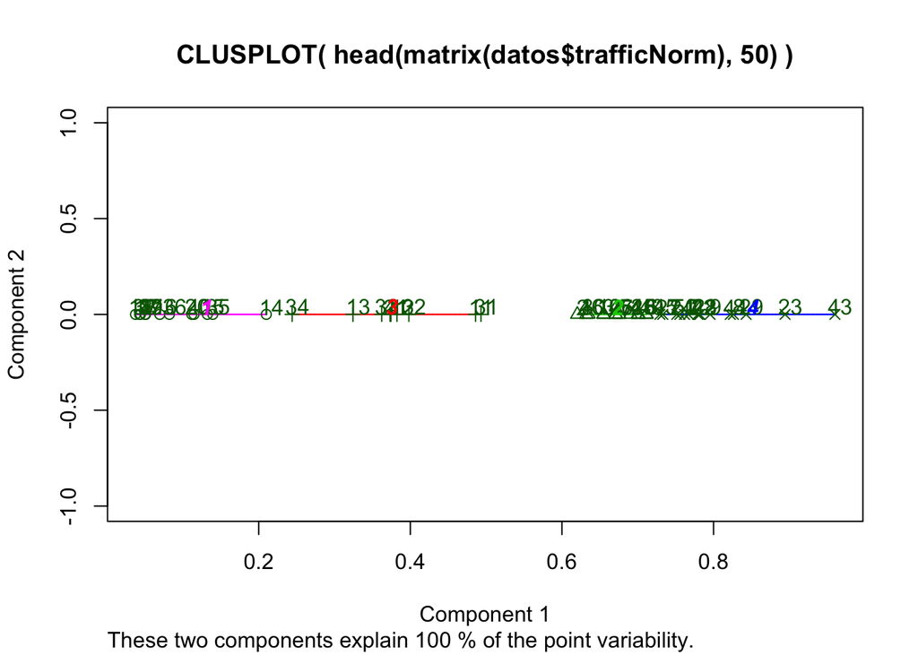

```r
clusplot(head(matrix(datos$trafficNorm),50), head(datos$nivelTrafico,50), color=TRUE, shade=TRUE, labels=2, lines=0)
```

Y vemos que “poco tráfico” es el grupo 1, “medio poco” el 3, “medio alto” el 2 y alto el 4. (Nótese que se fija la semilla para que los valores sean consistentes)

Lo traducimos al dataset para que quede más claro. Hacemos una doble manipulación de los datos para luego facilitar su visualización.

```r
datos$nivelTrafico <- gsub('1', 'Bajo', datos$nivelTrafico )
datos$nivelTrafico <- gsub('2', 'Medio alto', datos$nivelTrafico )
datos$nivelTrafico <- gsub('3', 'Medio bajo', datos$nivelTrafico )
datos$nivelTrafico <- gsub('4', 'Alto', datos$nivelTrafico )
datos$nivelTrafico <- as.factor(datos$nivelTrafico )
#Cambiamos el orden de los factores para que la visualización resute mejor posteriormente al estar ordenada lógicamente en lugar de alfabéticamente
datos$nivelTrafico = factor(datos$nivelTrafico, levels=c('Alto', 'Medio alto', 'Medio bajo', 'Bajo'))
```

Una vez que hemos llevado a cabo la preparación de los datos, me dispongo al análisis exploratorio de los mismos.

Mediante un boxplot podemos ver la distribución de los valores del tráfico

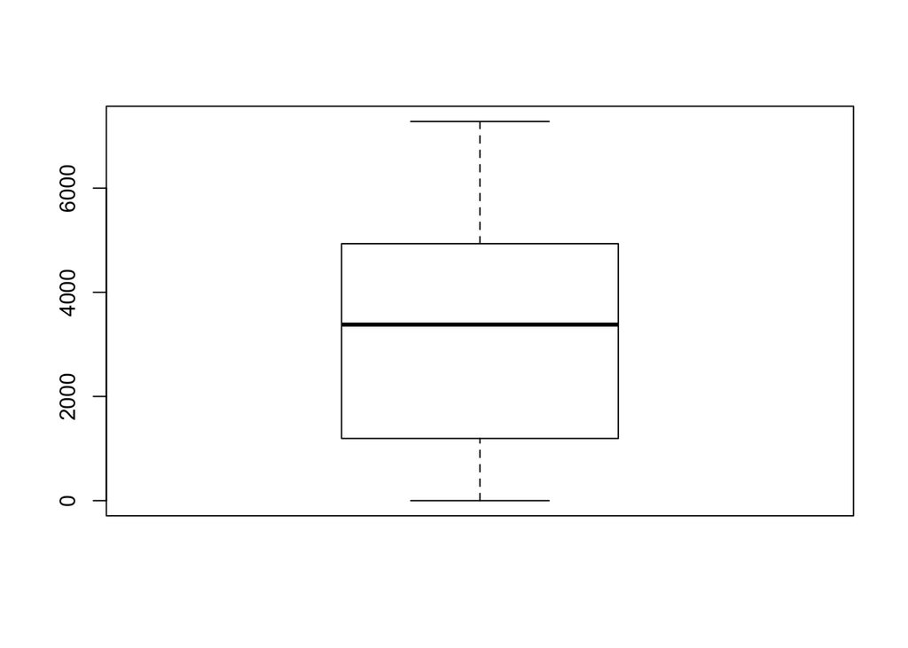

```r
#Distribución del tráfico en general
boxplot(datos$traffic_volume)
```

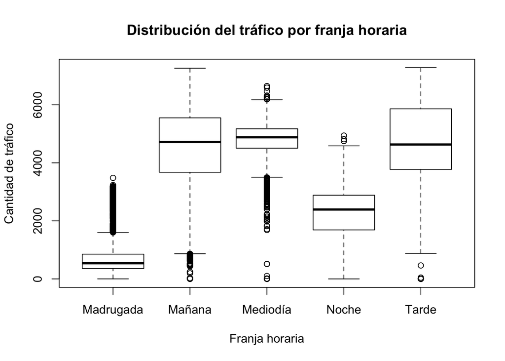

```r
#Ahora por franjas horarias
boxplot(datos$traffic_volume ~ datos$franjaHoraria,  ylab="Cantidad de tráfico", xlab="Franja horaria", main="Distribución del tráfico por franja horaria")
```

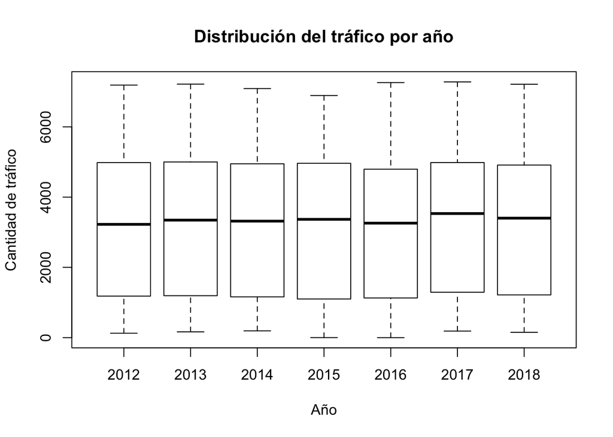

```r
#Por años
boxplot(datos$traffic_volume ~ datos$anio,  ylab="Cantidad de tráfico", xlab="Año", main="Distribución del tráfico por año")
```

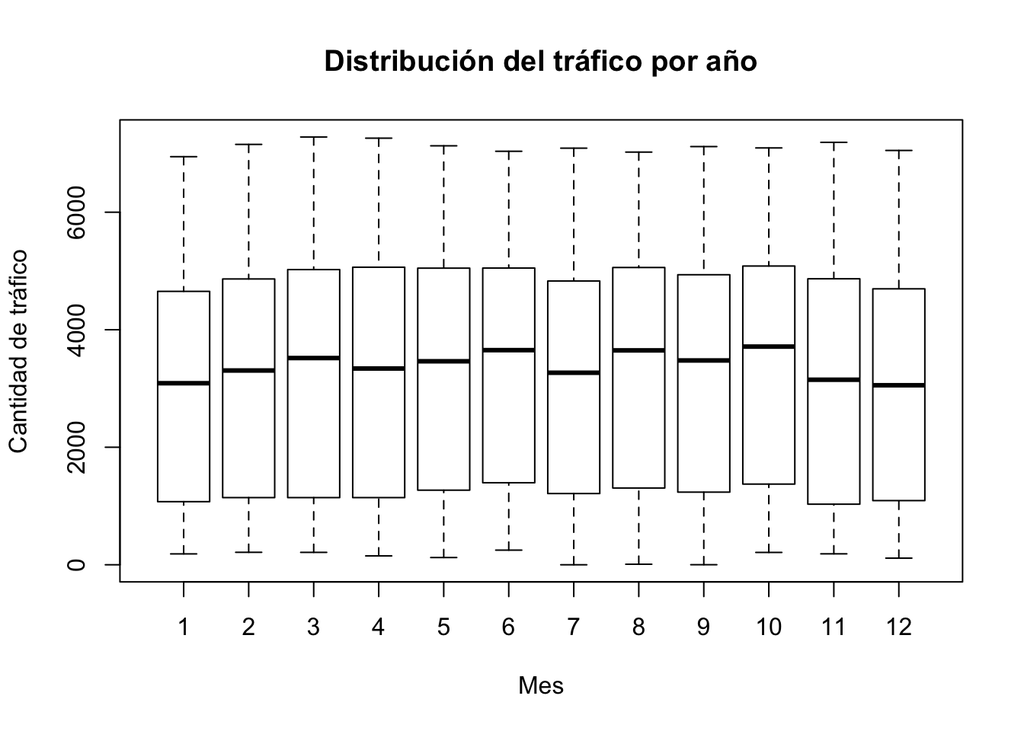

```r
#Por meses
boxplot(datos$traffic_volume ~ datos$mes,  ylab="Cantidad de tráfico", xlab="Mes", main="Distribución del tráfico por año")
```

En cuanto a los meses y los años, se observan diferencias pero a primera vista no demasiado significativas. En 2016 se observó un pequeño decremento de tráfico y en los meses de julio (vacaciones de verano) y diciembre y enero (Navidad) se observa también una menor afluencia de vehículos.

A continuación vamos a usar algunos gráficos de barras para ver los mismos datos pero con otros matices. Hago uso de la variable “nivelTrafico” en la que he guardado categorizado ese nivel.

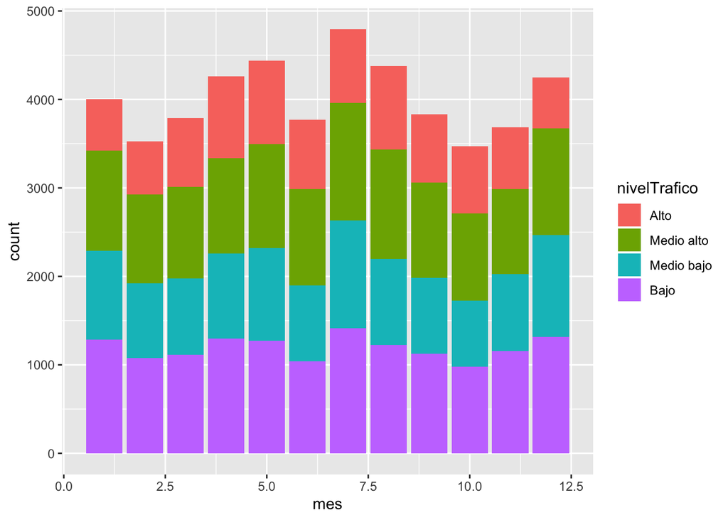

```r
#En cada mes
ggplot (data = datos, aes(x=mes, fill=nivelTrafico))+geom_bar()
```

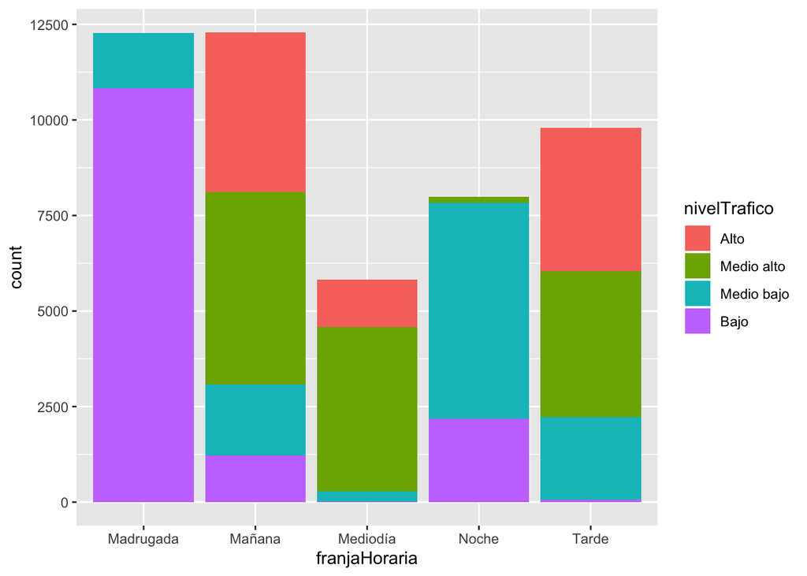

```r
#Por franjas horarias
ggplot (data = datos, aes(x=franjaHoraria, fill=nivelTrafico))+geom_bar()
```

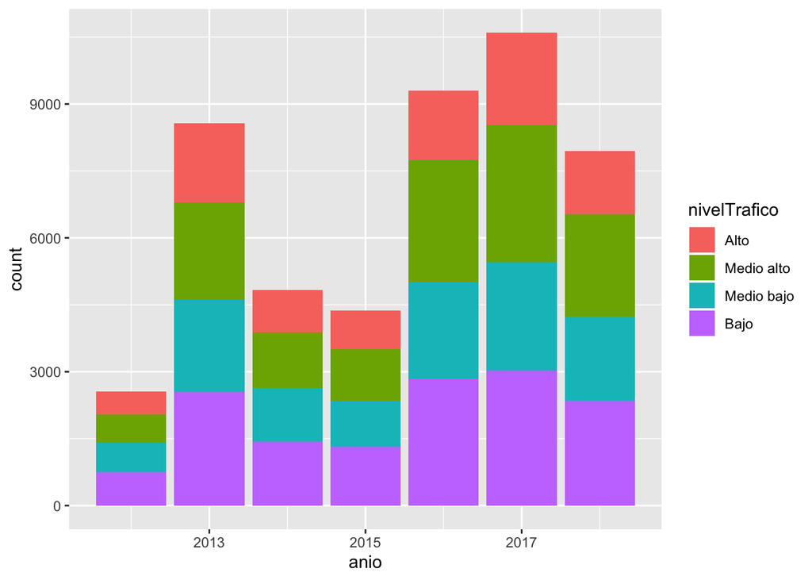

```r
#Por años
ggplot (data = datos, aes(x=anio, fill=nivelTrafico))+geom_bar()
```

De este último gráfico se obtiene algo importante: no existe la misma cantidad de mediciones para todos los años. Se aprecia claramente que en 2017 se computaron más del doble de datos que en 2015 (2012 es normal porque no se disponían de datos de todo el año). Por tanto, en el gráfico aparecen muchos más momentos de tráfico alto en 2017 que en 2012 pero la diferencia no parece muy significativa desde el punto de vista de la proporción.

Por último, vamos a ofrecer un diagrama del nivel de tráfico por franjas horarias para cada uno de los años para los que disponemos de observaciones:

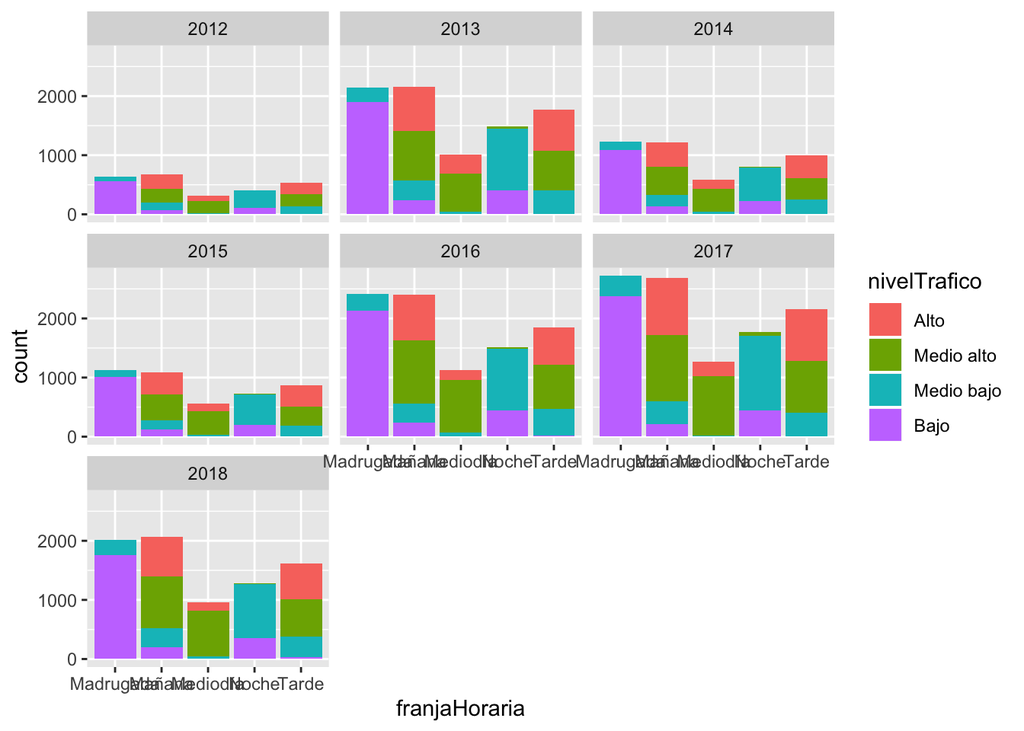

```r
ggplot (data = datos, aes(x=franjaHoraria, fill=nivelTrafico))+geom_bar()+facet_wrap(datos$anio)
```

Y aunque no sea el propósito inicial del dataset, vamos a obterner una idea de las temperaturas para cada mes del año:

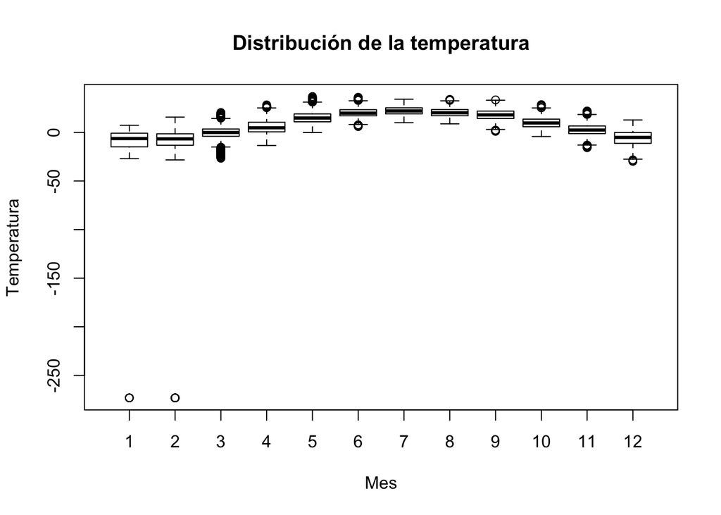

```r
boxplot(datos$temp ~ datos$mes,  ylab="Temperatura", xlab="Mes", main="Distribución de la temperatura")
```

Esto nos permite detectar un error en los datos. Hay algunas mediciones que tienen un 0 en la temperatura. Seguramente se debe a mediciones que no se realizaron y sin embargo se rellenó con un 0 (lo cual es claramente un error porque en Kelvin equivale a -273 grados.)

De una inspección de los datos se observa que son tan solo 11 registros los que tienen ese valor, por lo que aunque no seamos extremadamente rigurosos en el tratamiento no van a afectar notablemente a los resultados.

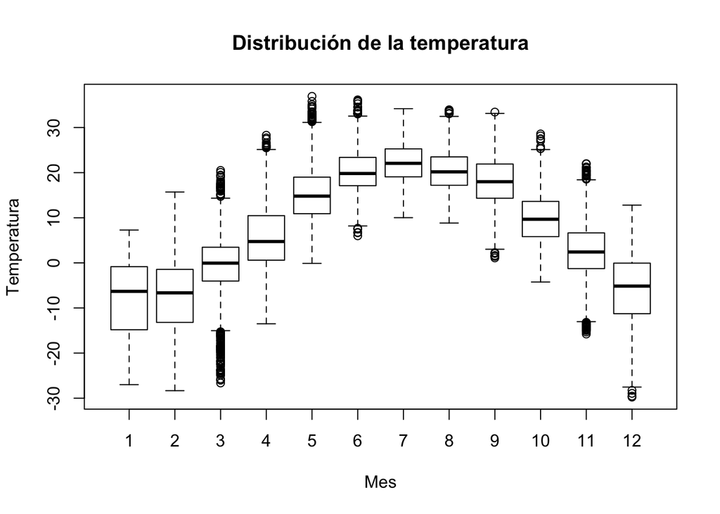

```r
#En primer lugar pongo como NA
for(i in 1:length(datos$temp)){
if (datos$temp[i]<=-100) {
  datos$temp[i] <- NA
}
}

#Vuelvo a ejecutar el gráfico, que ahora sí nos da unos valores más fácilmente comprensibles.
boxplot(datos$temp ~ datos$mes,  ylab="Temperatura", xlab="Mes", main="Distribución de la temperatura")
```

Vamos a hacer lo mismo con las lluvias:

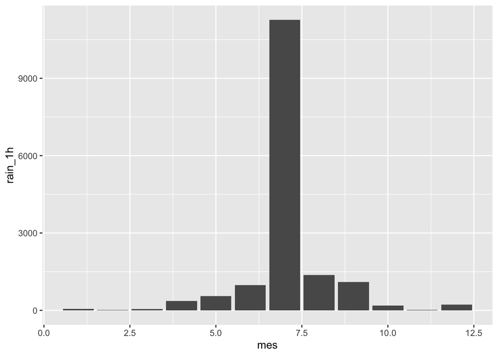

```r
#Utilizamos la estadística "identity" para sumar los valores por meses.
ggplot (data = datos, aes(x=mes, y=rain_1h))+geom_bar(stat = "identity")
```

De este gráfico vemos claramente algo muy extraño en el mes de julio.

Revisando el dataset vemos que hay un registro que tiene un valor de la cantidad de lluvia realmente anómalo:

```r
datos[24870, ]
```

```
##       holiday  temp rain_1h snow_1h clouds_all weather_main weather_description
## 24873    None 28.96  9831.3       0         75         Rain     very heavy rain
##                 date_time traffic_volume anio mes hora franjaHoraria
## 24873 2016-07-11 17:00:00           5535 2016   7   17         Tarde
##       trafficNorm nivelTrafico
## 24873   0.7603022         Alto
```

Vamos a eliminarlo y ejecutamos de nuevo.

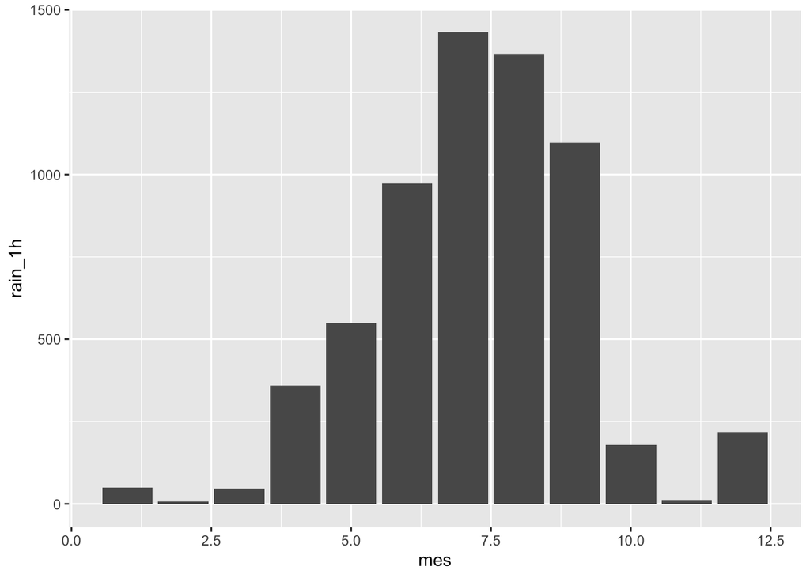

```r
datos$rain_1h[24870] <- NA
ggplot (data = datos, aes(x=mes, y=rain_1h))+geom_bar(stat = "identity")
```

Lo cual nos aporta una gráfica más realista en la que vemos que los meses de más lluvia son los de verano.

Por último, vamos a ver qué sucede con las nieves.

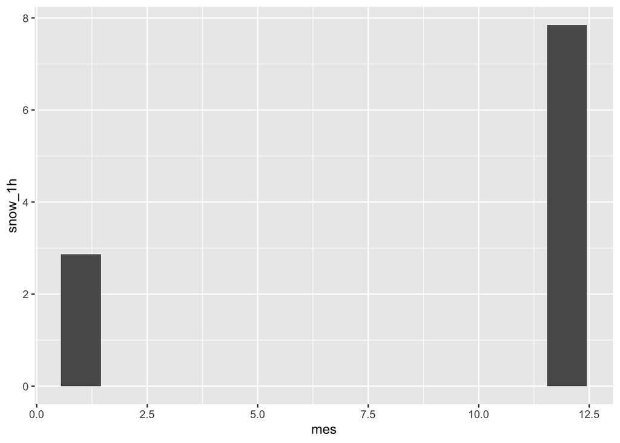

```r
ggplot (data = datos, aes(x=mes, y=snow_1h))+geom_bar(stat = "identity")
```

De una rápida inspección se observa que las nieves son escasas y solo localizadas en los meses de diciembre y enero.

A partir de esta manipulación en el conjunto de de datos, hemos hecho un estudio preliminar para ver en qué meses del año y franjas del día hay más tráfico y la distribución del mismo. También se ha estudiado desde el punto de vista de los años, donde hemos observado que no hay diferencias significativas entre unos y otros.

Por último hemos obtenido una gráfica que nos da una idea de las condiciones climatológicas en cada mes.

> Análisis PCA - SVD.

Adicionalmente y para concluir voy a tratar de realizar un análisis PCA y SVD de las variables del dataset. He dejado este punto para el final como investigación de un tema que no he tratado hasta ahora y del que no sé exactamente qué valores voy a obtener.

Ambas técnicas permiten crear nuevas variables en función de las variables originales del dataset. Posteriormente, de su análisis, se puede reducir la dimensionalidad de la muestra de datos.

Para ello, el dataset debe ser numérico. Vamos a intentar ver qué tiene más peso entre las variables referidas a la climatología que son cuantificables (temperatura, lluvia, nieve y porcentaje de nubosidad).

Vamos a usar la función prcomp, que centra los datos con la media en 0. Indicamos scale para que su desviación estándar sea 1

```r
datosClima<-select (datosCopia, temp, rain_1h, snow_1h, clouds_all)
pca<-prcomp(datosClima, scale = TRUE )
pca$rotation
```

```
##                    PC1        PC2        PC3         PC4
## temp       -0.67220848 0.07913597  0.2370493  0.69690811
## rain_1h    -0.02529337 0.98745679 -0.1240645 -0.09432574
## snow_1h     0.28803982 0.12092514  0.9481553 -0.05840975
## clouds_all  0.68156370 0.06359013 -0.1715144  0.70852667
```

La variable rotation de pca nos ofrece información sobre los pesos que cada una de las componentes generadas por la función le otorgan a cada variable del dataset.

Por ejemplo, llama la atención cómo la PC2 da un peso muchísimo mayor a la lluvia que al resto de factores mientras que el PC3 se lo da a la nieve.

A continuación vamos a analizar la desviación estándar y la varianza de cada componente principal.

```r
pca$sdev^2
```

```
## [1] 1.1122019 1.0010260 0.9900202 0.8967518
```

```r
varianza <- pca$sdev^2 / sum(pca$sdev^2)
```

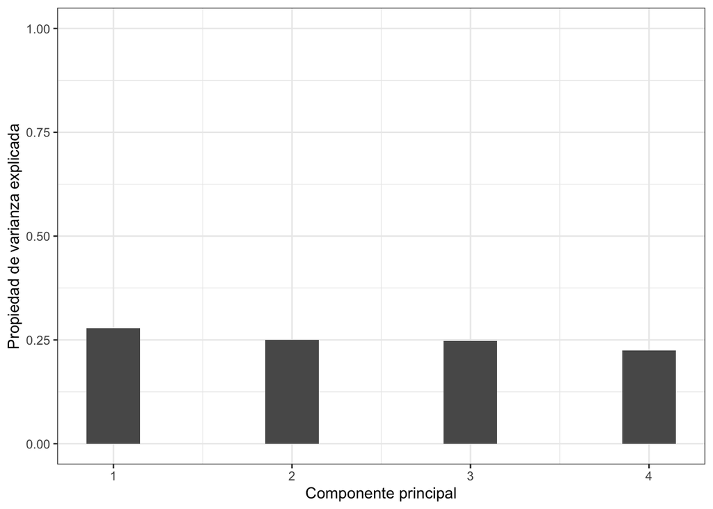

```r
ggplot(data = data.frame(varianza, pc = 1:4),
       aes(x = pc, y = varianza)) +
  geom_col(width = 0.3) +
  scale_y_continuous(limits = c(0,1)) +
  theme_bw() +
  labs(x = "Componente principal",
       y = "Propiedad de varianza explicada")
```

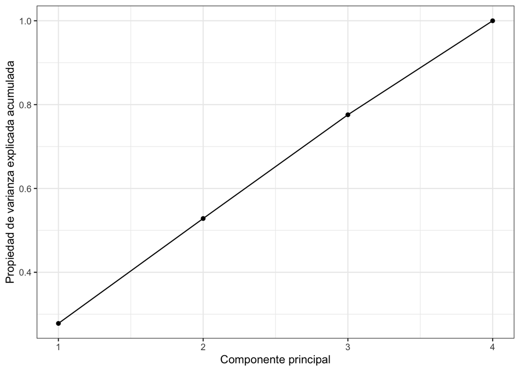

```r
#La función cumsum acumula las sumas de los elementos del vector
varianza_acum <- cumsum(varianza)

ggplot(data = data.frame(varianza_acum, pc = 1:4),
       aes(x = pc, y = varianza_acum, group = 1)) +
  geom_point() +
  geom_line() +
  theme_bw() +
  labs(x = "Componente principal",
       y = "Propiedad de varianza explicada acumulada")
```

Este gráfico nos demuestra que para este dataset no hay ninguna variable que explique la varianza de los datos, pues todos tienen unos valores parecidos. La primera comoponente podría explicar el 28% de los datos, mientras que la cuarta, aproximadamente el 22.

En cierto modo, esto parece razonable, puesto que estamos hablando de variables climáticas que guardan cierta relación entre sí.

Vamos a ver qué sucede con svd.

Single Value Descomposition es una técnica de descomposición de factores de una matriz.

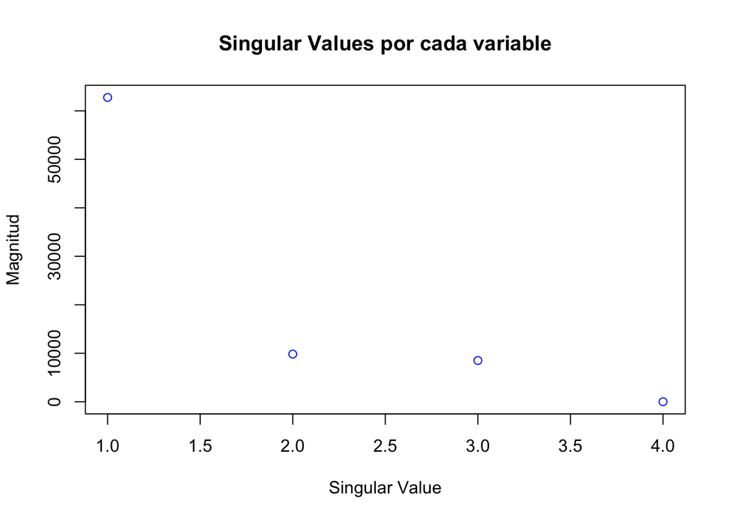

```r
svd <- svd(datosClima)

#Mostramos los valores de la diagonal de la matriz (que ya está ordenada y contiene los valores singulares)
plot(svd$d, col = "blue", xlab='Singular Value', ylab='Magnitud', main = "Singular Values por cada variable")
```

La matriz “d” de la que se obtienen los datos es la diagonal de los valores singulares, viendo cómo el valor se reduce llamativamente entre el primero y el último.

En este caso, tan solo estoy tratando 4 variables, pero voy a intentar hacer el estudio de si es posible reducir la funconalidad.

Para ello, eiste un método que calcula la suma de los cuadrados de todos los valores singulares y vemos si la suma de solo alguno de los principales elementos de la matriz (están ordenados decrecientemente) contiene un porcentaje alto del valor de la suma total:

```r
#Suma acumulada de todos los valores de la matriz
sumaTotalCuadrados <- sum(svd$d^2)
#Suma de los dos primeros
suma2Cuadrados <- sum(svd$d[1:2]^2)
#Suma de los tres primeros
suma3Cuadrados <- sum(svd$d[1:3]^2)

#Vemos el porcentaje en cada caso.
suma2Cuadrados/sumaTotalCuadrados
```

```
## [1] 0.9824033
```

```r
suma3Cuadrados/sumaTotalCuadrados
```

```
## [1] 1
```

Vemos que con las tres primeras variables tenemos prácticamente el 100% de las variaciones de datos explicadas por lo que se podría reducir la dimensionalidad aplicando esta técnica.

# 4 Propiedad intelectual:

Para el desarrollo de esta actividad, se ha obtenido el dataset de la página https://archive.ics.uci.edu/ml/datasets/Metro+Interstate+Traffic+Volume

Para consultas de programación en R se ha buscado en foros y la ayuda de R Documentation.

Para el estudio PCA se han utilizado las siguientes páginas como referencia:

https://towardsdatascience.com/understanding-singular-value-decomposition-and-its-application-in-data-science-388a54be95d (conceptos teóricos de SVD) https://stats.idre.ucla.edu/r/codefragments/svd_demos/ (conceptos SVD) https://rpubs.com/Joaquin_AR/287787 (guía para la realización de un estudio PCA en R)

Para SVD:

https://rpubs.com/jt_rpubs/287285 https://stats.idre.ucla.edu/r/codefragments/svd_demos/